# Hands On: Introduction to MATLAB - Part 5 - LTI Systems

This is the fifth MATLAB live script of the collection Hands On: Using MATLAB in the 267MI "System Dynamics" course, devoted to introduce the MATLAB/Simulink environment and tools for solving practical problems related to the topics of the 267MI course, i.e. performance analysis of dynamic systems, parametric estimation, identification of models from data, and prediction of the evolution of dynamic systems.

Use this link to go back to the main live script of the collection.

Table of Contents

Objectives Time Invariant Linear Dynamic Systems LTI-System Object from the State-Space Description A few Examples LTI-System Object from the Transfer Function A few Examples Alternative Way of Using the tf Command Simulation of LTI Systems First Example: Forced Output Movement of a Continuous-Time System An Exercise Another Example: Step Response of a Sampled-Time LTI System Summary Back to the Index Back to the Previous Part: Functions

## Objectives

The aim of this module is to understand how to create and manipulate LTI systems in MATLAB.

## Time Invariant Linear Dynamic Systems

AN LTI system can be described

- using a state-space description
- using the transfer function matrix for a MIMO system or a single transfer function for a SISO system

In MATLAB, it is possible to define a linear time-invariant dynamical system as an object of type LTI model from any of these descriptions (use help ltimodels for details] ). Using these MATLAB objects, it is possible to analyze the properties of the corresponding dynamic system, and also to simulate the evolution of the dynamic system over time with assigned initial conditions and inputs.

From now on, for simplicity, we only consider SISO systems.

### LTI-System Object from the State-Space Description

Starting from the state equation, you can

- define the matrices A, B, C, D of the state equations in the MATLAB workspace;
- define the LTI system by means of the command ss

```matlab
help ss
```

**ss** State-space models. Construction: SYS = **ss**(A,B,C,D) creates an object SYS representing the continuous- time state-space model dx/dt = Ax(t) + Bu(t) y(t) = Cx(t) + Du(t) You can set D=0 to mean the zero matrix of appropriate size. SYS is of type **ss** when A,B,C,D are dense numeric arrays, of type GENSS when A,B,C,D depend on tunable parameters (see REALP and GENMAT), and of type USS when A,B,C,D are uncertain matrices (requires Robust Control Toolbox). Use SPARSS when A,B,C,D are sparse matrices. SYS = **ss**(A,B,C,D,Ts) creates a discrete-time state-space model with sample time Ts (set Ts=-1 if the sample time is undetermined). SYS = **ss**(D) specifies a static gain matrix D. You can set additional model properties by using name/value pairs. For example, sys = ss(-1,2,1,0,'InputDelay',0.7,'StateName','position') also sets the input delay and the state name. Type "properties(ss)" for a complete list of model properties, and type help ss.<PropertyName> for help on a particular property. For example, "help ss.StateName" provides information about the "StateName" property. Arrays of state-space models: You can create arrays of state-space models by using ND arrays for A,B,C,D. The first two dimensions of A,B,C,D define the number of states, inputs, and outputs, while the remaining dimensions specify the array sizes. For example, sys = ss(rand(2,2,3,4),[2;1],[1 1],0) creates a 3x4 array of SISO state-space models. You can also use indexed assignment and STACK to build **ss** arrays: sys = ss(zeros(1,1,2)) % create 2x1 array of SISO models sys(:,:,1) = rss(2) % assign 1st model sys(:,:,2) = ss(-1) % assign 2nd model sys = stack(1,sys,rss(5)) % add 3rd model to array Conversion: SYS = **ss**(SYS) converts any dynamic system SYS to the state-space representation. The resulting model SYS is always of class **ss**. SYS = **ss**(SYS,'min') computes a minimal realization of SYS. SYS = **ss**(SYS,'explicit') computes an explicit realization (E=I) of SYS. An error is thrown if SYS is improper. See also dss, delayss, rss, drss, sparss, mechss, ssdata, tf, zpk, frd, genss, uss, DynamicSystem. Documentation for ss Other uses of ss

#### A few Examples

Given the following state-space description of a continuous-time dynamical system

$\left\{ \begin{array}{lcl} \dot{x}_1(t)&=& -x_2(t)+3 u(t)\\ \dot{x}_2(t)&=& -3 x_1(t)+2 x_2(t)\\ y(t)&=& 4 x_1(t)+2 u(t) \end{array} \right.$

the corresponding MATLAB object is given by

```matlab
A = [0 -1;-3 2]; B = [3;0]; C=[4 0]; D=2; % the system matrices
sysC = ss(A, B, C, D)
```

sysC = A = x1 x2 x1 0 -1 x2 -3 2 B = u1 x1 3 x2 0 C = x1 x2 y1 4 0 D = u1 y1 2 Continuous-time state-space model.

Consider a discrete time dynamical system, described by the model

$\left\{ \begin{array}{lcl} x_1(k+1)&=& -x_2(k)+3 u(k)\\ x_2(k+1)&=& -3 x_1(k)+2 x_2(k)\\ y(k)&=& 4 x_1(k)+2 u(k) \end{array} \right.$

then

```matlab
A = [0 -1;-3 2]; B = [3;0]; C=[4 0]; D=2; % the system matrices
sysD = ss(A, B, C, D, -1) % the sampling time is unpsecified
```

sysD = A = x1 x2 x1 0 -1 x2 -3 2 B = u1 x1 3 x2 0 C = x1 x2 y1 4 0 D = u1 y1 2 Sample time: unspecified Discrete-time state-space model.

### LTI-System Object from the Transfer Function

Given a transfer function as model for an LTI system, you can create an LTImodel object by using the tf command:

```matlab
help tf
```

**tf** Construct transfer function or convert to transfer function. Construction: SYS = **tf**(NUM,DEN) creates a continuous-time transfer function SYS with numerator NUM and denominator DEN. SYS is an object of type **tf** when NUM,DEN are numeric arrays, of type GENSS when NUM,DEN depend on tunable parameters (see REALP and GENMAT), and of type USS when NUM,DEN are uncertain (requires Robust Control Toolbox). SYS = **tf**(NUM,DEN,TS) creates a discrete-time transfer function with sample time TS (set TS=-1 if the sample time is undetermined). S = **tf**('s') specifies the transfer function H(s) = s (Laplace variable). Z = **tf**('z',TS) specifies H(z) = z with sample time TS. You can then specify transfer functions directly as expressions in S or Z, for example, s = tf('s'); H = exp(-s)*(s+1)/(s^2+3*s+1) SYS = **tf** creates an empty **tf** object. SYS = **tf**(M) specifies a static gain matrix M. You can set additional model properties by using name/value pairs. For example, sys = tf(1,[1 2 5],0.1,'Variable','q','IODelay',3) also sets the variable and transport delay. Type "properties(tf)" for a complete list of model properties, and type help tf.<PropertyName> for help on a particular property. For example, "help tf.Variable" provides information about the "Variable" property. By default, transfer functions are displayed as functions of 's' or 'z'. Alternatively, you can use the variable 'p' in continuous time and the variables 'z^-1', 'q', or 'q^-1' in discrete time by modifying the "Variable" property. Data format: For SISO models, NUM and DEN are row vectors listing the numerator and denominator coefficients in descending powers of s,p,z,q or in ascending powers of z^-1 (DSP convention). For example, sys = tf([1 2],[1 0 10]) specifies the transfer function (s+2)/(s^2+10) while sys = tf([1 2],[1 5 10],0.1,'Variable','z^-1') specifies (1 + 2 z^-1)/(1 + 5 z^-1 + 10 z^-2). For MIMO models with NY outputs and NU inputs, NUM and DEN are NY-by-NU cell arrays of row vectors where NUM{i,j} and DEN{i,j} specify the transfer function from input j to output i. For example, H = tf( {-5 ; [1 -5 6]} , {[1 -1] ; [1 1 0]}) specifies the two-output, one-input transfer function [ -5 /(s-1) ] [ (s^2-5s+6)/(s^2+s) ] Arrays of transfer functions: You can create arrays of transfer functions by using ND cell arrays for NUM and DEN above. For example, if NUM and DEN are cell arrays of size [NY NU 3 4], then SYS = **tf**(NUM,DEN) creates the 3-by-4 array of transfer functions SYS(:,:,k,m) = **tf**(NUM(:,:,k,m),DEN(:,:,k,m)), k=1:3, m=1:4. Each of these transfer functions has NY outputs and NU inputs. To pre-allocate an array of zero transfer functions with NY outputs and NU inputs, use the syntax SYS = **tf**(ZEROS([NY NU k1 k2...])) . Conversion: SYS = **tf**(SYS) converts any dynamic system SYS to the transfer function representation. The resulting SYS is always of class **tf**. See also tf/exp, filt, tfdata, zpk, ss, frd, genss, uss, DynamicSystem. Documentation …

#### A few Examples

Consider the LTI systems

$G_1(s) = \displaystyle \frac{s+1}{s^2+3s+16} \qquad \qquad G_2(z) = \displaystyle \frac{(z+1.0)\,(z+0.4)}{(z-1)\,(z+0.8)}$

then

```matlab
numG1 = [ 1 1 ]; denG1 = [ 1 3 16 ];
G1 = tf(numG1, denG1)
```

G1 = s + 1 -------------- s^2 + 3 s + 16 Continuous-time transfer function.

```matlab
numG2 = conv([1 1],[1 0.4]); denG2 = conv([1  -1],[1  0.8]);
G2 = tf(numG2, denG2, -1)
```

G2 = z^2 + 1.4 z + 0.4 ----------------- z^2 - 0.2 z - 0.8 Sample time: unspecified Discrete-time transfer function.

#### Alternative Way of Using the tf Command

Continuous-time and discrete-time ''elementary'' transfer functions can be defined, and used as ''building blocks'' in writing the expressions of the actual transfer functions.

Consider

```matlab
s=tf('s');
Gs = exp(-2*s) * (s+1)/(s^2+3*s+2)
```

Gs = s + 1 exp(-2*s) * ------------- s^2 + 3 s + 2 Continuous-time transfer function.

In the discrete time case

$H(z) = z^{-3}\, \displaystyle \frac{(z+1.0)\,(z+0.4)}{(z-1)\,(z+0.8)}$

```matlab
z = tf('z',-1);
Hz = z^(-3)*(z+1)*(z+0.4)/(z-1)/(z+0.8)
```

Hz = z^2 + 1.4 z + 0.4 ----------------------- z^5 - 0.2 z^4 - 0.8 z^3 Sample time: unspecified Discrete-time transfer function.

## Simulation of LTI Systems

The following MATLAB commands are available, both for continuos-time and discrete-time LTI system:

- impulse: simulation of impulse response;
- step: simulation of the step response;
- initial: simulation of the free state and output movements;
- lsim: simulation of the forced movements.

### First Example: Forced Output Movement of a Continuous-Time System

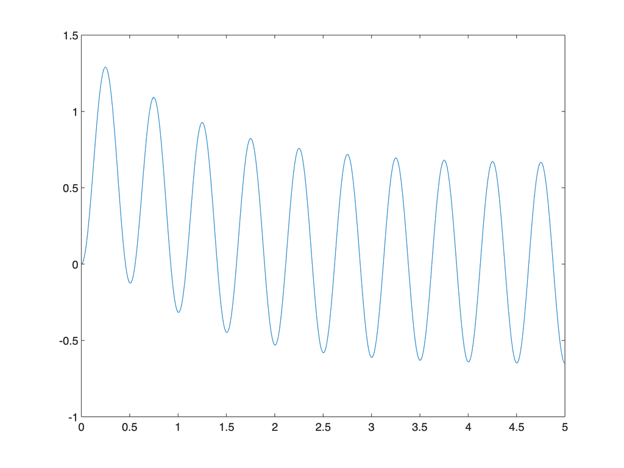

```matlab
a=[-1 ,0;3,-4];
b=[2;1];
c=[1,2];d=0; % the system matrices
sysC = ss(a,b,c,d); % the LTI system object

t=(0:0.01:5); % a vector contining some time instants
u=2*sin(2*pi*2*t); % the corresponding input values

y=lsim(sysC,u,t); % evaluate the forced output movement

plot(t,y); % plotting the results
```

### An Exercise

Write a piece of code for the evaluation of the free state movement of the system, starting from a random initial state.

Hint: have a look to

```matlab
help initial
```

**initial** Initial condition response of state-space models. **initial**(SYS,X0) plots the undriven response of the state-space model SYS (created with SS) with initial condition X0 on the states. This response is characterized by the equations . Continuous time: x = A x , y = C x , x(0) = x0 Discrete time: x[k+1] = A x[k], y[k] = C x[k], x[0] = x0 . The time range and number of points are chosen automatically. **initial**(SYS,X0,TFINAL) simulates the time response from t=0 to the final time t=TFINAL (expressed in the time units specified in SYS.TimeUnit). For discrete-time models with unspecified sample time, TFINAL is interpreted as the number of sampling periods. **initial**(SYS,X0,T) uses the time vector T for simulation (expressed in the time units of SYS). For discrete-time models, T should be of the form Ti:Ts:Tf where Ts is the sample time. For continuous-time models, T should be of the form Ti:dt:Tf where dt is the sampling period for the discrete approximation of SYS. **initial**(SYS1,SYS2,...,X0,T) plots the response of several systems SYS1,SYS2,... on a single plot. The time vector T is optional. You can also specify a color, line style, and marker for each system, for example: initial(sys1,'r',sys2,'y--',sys3,'gx',x0). When invoked with left hand arguments, [Y,T,X] = **initial**(SYS,X0) returns the output response Y, the time vector T used for simulation, and the state trajectories X. No plot is drawn on the screen. The matrix Y has LENGTH(T) rows and as many columns as outputs in SYS. Similarly, X has LENGTH(T) rows and as many columns as states. The time vector T is expressed in the time units of SYS. See also initialplot, impulse, step, lsim, ltiview, DynamicSystem. Documentation for initial Other uses of initial

```matlab
% insert here the code
```

### Another Example: Step Response of a Sampled-Time LTI System

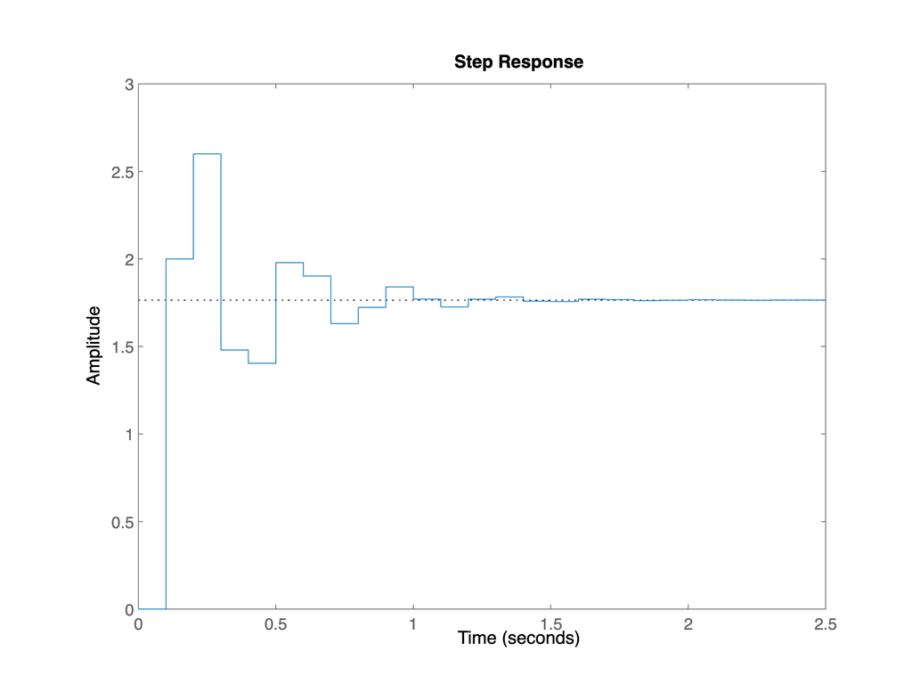

```matlab
% sampled time LTI system
Ts = 0.1; % the sampling period
sysD = tf([2 1],[1 0.2 0.5], Ts);

figure;step(sysD); % the step response
```

to be continued ...

## Summary

#### Back to the Index

Use this link to go back to the main live script of the collection.

#### Back to the Previous Part: Functions

Use this link to go back to the previous live script of this collection.